# Kruskal-Wallis Test

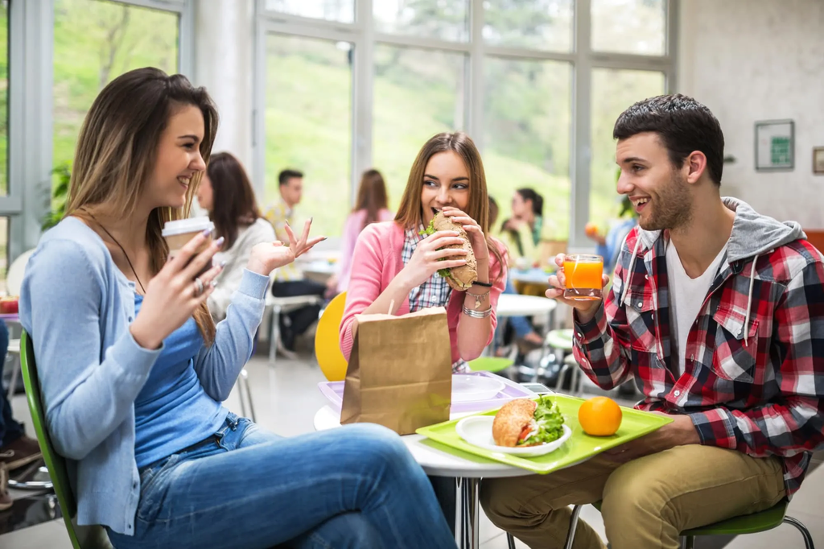

```r
# Import packages
library(mosaic) # for the favstats
library(car)
library(DT)
library(pander)
library(readr)
library(ggplot2)

# load data
food <- read_csv("food.csv")
```

## Background

The **Kruskal-Wallis Test** compares the median (middle values) of different groups of data that are not normally distributed. It works by **ranking all the data from all the groups together and then comparing the ranks between the groups.** This test is used when the data is not normally distributed and doesn’t meet the requirements of the one-way analysis of variance (ANOVA) test.

## Introduction

In this case study, I am going to test if there is a **relation between the student’s GPA score and the nutritional check group**, which is the frequency of when the students check nutritional facts of food.

Non-parametric test:

$$H_0: \text{The median GPA scores of students in all nutritional
checking frequency groups are equal.}$$

$$H_a: \text{The median GPA scores of at least one nutritional checking
frequency group are different from the others.}$$

Significance level for this study will be set at:

$$\alpha = 0.05$$

Questions about the data:

- Does having a higher nutritional value frequency result in a higher GPA score?
- Is there a significant difference in the GPA scores based on the frequency of nutritional value checks?
- Do students who check the nutritional facts more often have higher GPA scores?

These inquiries are focused on a particular analysis that will be computed using the Kruskal-Wallis test.

## Analysis

```r
# new dataset with columns I will be using
food_analysis_selection <- food %>%
  select(c('GPA', 'nutritional_check'))

# fix the missing data and/or misspelling

# value 'Personal'   on row 62  was changed to 'NA'   and it was ignored in the analysis.
food_analysis_selection$GPA[62 ] = NA
# value 'Unknown'    on row 105 was changed to 'NA'   and it was ignored in the analysis.
food_analysis_selection$GPA[105] = NA
# value '3.79 bitch' on row 74  was changed to '3.79' and it was part of    the analysis.
food_analysis_selection$GPA[74 ] = 3.79

# Label 'nutritional_check' groups
food_analysis_noFactor <- food_analysis_selection %>%
  mutate(
    nutritional_check = case_when(
      nutritional_check == '1' ~ "Never",
      nutritional_check == '2' ~ "Almost never",
      nutritional_check == '3' ~ "Sometimes",
      nutritional_check == '4' ~ "Almost always",
      nutritional_check == '5' ~ "Always"
    )
  )

# Convert nutritional_check column to qualitative values
# Convert GPA               column to numerical   values
food_analysis_factor_and_numeric <-  food_analysis_noFactor %>%
  mutate(
    nutritional_check = factor(nutritional_check, levels = c("Never", "Almost never", "Sometimes", "Almost always", "Always")),
    GPA = as.numeric(GPA)
  )

food_analysis <-  food_analysis_factor_and_numeric %>%
  select(c('GPA', 'nutritional_check')) %>%
  na.omit()
```

**Data Summary Table**

```r
# Kruskal-Test Analysis

pander(favstats(GPA ~ nutritional_check, data = food_analysis)[,-10],
       caption = "Summary Statistics for GPA by Nutritional Check Frequency",
       split.tables = Inf,
       keep.line.breaks = TRUE,
       style = "rmarkdown")
```

Summary Statistics for GPA by Nutritional Check Frequency

| nutritional_check | min | Q1 | median | Q3 | max | mean | sd | n |
| --- | --- | --- | --- | --- | --- | --- | --- | --- |
| Never | 2.2 | 3 | 3.2 | 3.292 | 3.6 | 3.016 | 0.4777 | 9 |
| Almost never | 2.71 | 3.2 | 3.5 | 3.685 | 3.92 | 3.435 | 0.3007 | 36 |
| Sometimes | 2.6 | 3.387 | 3.6 | 3.7 | 3.9 | 3.497 | 0.3553 | 20 |
| Almost always | 2.6 | 3 | 3.6 | 3.8 | 4 | 3.473 | 0.4061 | 41 |
| Always | 2.4 | 3.2 | 3.3 | 3.695 | 3.904 | 3.368 | 0.4239 | 15 |

**Box Plot Chat**

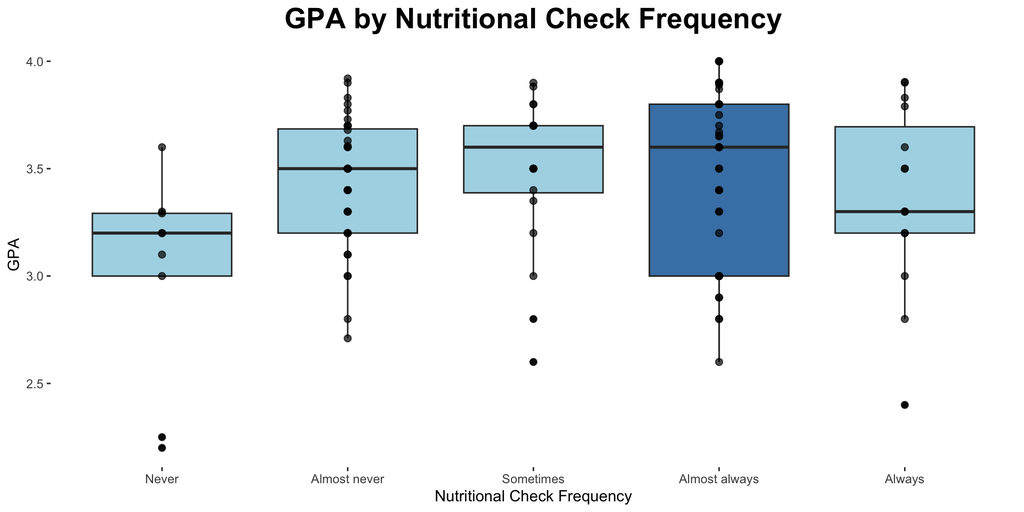

```r
ggplot(food_analysis, aes(x=nutritional_check, y=GPA)) +
  geom_boxplot(fill = "lightblue") +
  scale_x_discrete(labels=c("Never","Almost never","Sometimes","Almost always","Always")) +
  geom_boxplot(data=subset(food_analysis, nutritional_check == "Almost always"), fill = "steelblue") +
  geom_point(alpha = 0.7, size = 2) +
  labs(x = "Nutritional Check Frequency", y = "GPA", title = "GPA by Nutritional Check Frequency") +
  theme(panel.grid.major = element_blank(),
        panel.grid.minor = element_blank(),
        panel.background = element_rect(fill = "white"),
        plot.title = element_text(size = 20, face = "bold", hjust = 0.5))
```

**Kruskal-Wallis Test Procedure**

1. Rank the data from lowest to highest, combining all groups together.
2. Calculate the sum of ranks for each group.
3. Calculate the Kruskal-Wallis test statistic using the formula:

$$H = (12 / N(N+1)) * [∑(R_i^2 / n_i) - 3(N+1)]$$

Where:

- H is the Kruskal-Wallis test statistic
- N is the total number of observations
- R_i is the sum of ranks for the i-th group
- n_i is the sample size of the i-th group
4. Calculate the degrees of freedom using the formula: df = k - 1 where k is the number of groups.
5. Compare the calculated test statistic to the chi-square distribution with df degrees of freedom, and calculate the p-value.

```r
# Kruskal-Test Analysis
pander(kruskal.test(GPA ~ nutritional_check, data = food_analysis))
```

Kruskal-Wallis rank sum test: `GPA` by `nutritional_check`

| Test statistic | df | P value |
| --- | --- | --- |
| 9.188 | 4 | 0.05657 |

## Conclution

The Kruskal-Wallis rank sum test was used to investigate whether there is a significant difference in the median GPA scores among students in different nutritional check frequency groups. The test yielded a test statistic of 9.188 with 4 degrees of freedom and a p-value of 0.05657.

Since the p-value is greater than the significance level of 0.05, **we fail to reject the null hypothesis** that the median GPA scores of students in all nutritional checking frequency groups are equal.

Therefore, **we do not have sufficient evidence to conclude that there is a significant difference in the median GPA scores among students in different nutritional check frequency groups.**

However, it is worth noting that the p-value is relatively close to the significance level, suggesting that there may be a trend towards a difference in median GPA scores among the groups. Further investigation with a larger sample size may be necessary to confirm this.